# Final Project

Elena Liu

11/20/2021

## Brief Description:

##### The Racial and Social Equity Composite Index combines the information of education attainment, English fluency, race (foreign-born or not), health condition that potentially correlated socioeconomic level. The overall percentile with specific weight calculated by the factors above was compared with the actual socioeconomic percentile of the neighborhood to identify where propriety populations make up relatively large proportions of neighborhood residents.

#### Questions and hypothesis:

##### First of all, I found this very updated dataset an excellent source for analyzing each factor’s (race, health condition, English fluency, education attainment) relationship with socioeconomic status and the composite stutus, and the interrelationships of each other. I would like to compare different model to find the relatively the best one to fit. My hypothesis is that the linear regression would not be a reasonable fit for the categorical variable, and I would like to try the non-linear models including poisson and logistic regression models.Additionally, the variables I have chosen have a negative correlation with socialeconomic and composite quantile. Also, there should be a positive correlation between socialeconomic quantile and composite quantile.

##### Link: https://catalog.data.gov/dataset/racial-and-social-equity-composite-index

##### Data.gov. (2020–2021, November 10–September 17). Racial and Social Equity Composite Index - CKAN [Dataset]. City of Seattle GIS Program. https://catalog.data.gov/dataset/racial-and-social-equity-composite-index

## Discribe variables

#### 1.The first numerical variable I would like to include in my analysis is the percentage of people in color of the neighbourhood.The range of this variable , since it is a percentage, is from 0 to 1.

```r
library(tidyverse)
rawdata<-read_csv("/Users/elenaliu/Desktop/Racial_and_Social_Equity_Composite_Index.csv")
as_tibble(rawdata)
```

```
## # A tibble: 135 × 39
##    OBJECTID     GEOID10 NAME10 NAMELSAD10         ACRES_TOTAL PCT_PEOPLE_OF_COL…
##       <dbl>       <dbl>  <dbl> <chr>                    <dbl>              <dbl>
##  1        1 53033005900   59   Census Tract 59          448.               0.185
##  2        2 53033004700   47   Census Tract 47          491.               0.181
##  3        3 53033001900   19   Census Tract 19          411.               0.302
##  4        4 53033001300   13   Census Tract 13          293.               0.405
##  5        5 53033004100   41   Census Tract 41          788.               0.164
##  6        6 53033005000   50   Census Tract 50          187.               0.190
##  7        7 53033004302   43.0 Census Tract 43.02        81.7              0.429
##  8        8 53033008200   82   Census Tract 82           90.6              0.372
##  9        9 53033007500   75   Census Tract 75          198.               0.291
## 10       10 53033007700   77   Census Tract 77          262.               0.281
## # … with 125 more rows, and 33 more variables: PTL_PEOPLE_OF_COLOR <dbl>,
## #   PCT_ENGLISH_LESSTHAN_VERY_WELL <dbl>, PTL_ENGLISH_LESSTHAN_VERY_WELL <dbl>,
## #   PCT_FOREIGN_BORN <dbl>, PTL_FOREIGN_BORN <dbl>,
## #   PCT_POP_INC_UNDER_200_POVERTY <dbl>, PTL_POP_INC_UNDER_200_POVERTY <dbl>,
## #   PCT_LESS_BACHELOR_DEGREE <dbl>, PTL_LESS_BACHELOR_DEGREE <dbl>,
## #   PCT_ADULTNOLEISUREPHYSACTIVITY <dbl>, PCT_ADULT_WITH_DIABETES <dbl>,
## #   PCT_ADULT_OBESE <dbl>, PCT_ADULTMENTALHEALTHNOTGOOD <dbl>, …
```

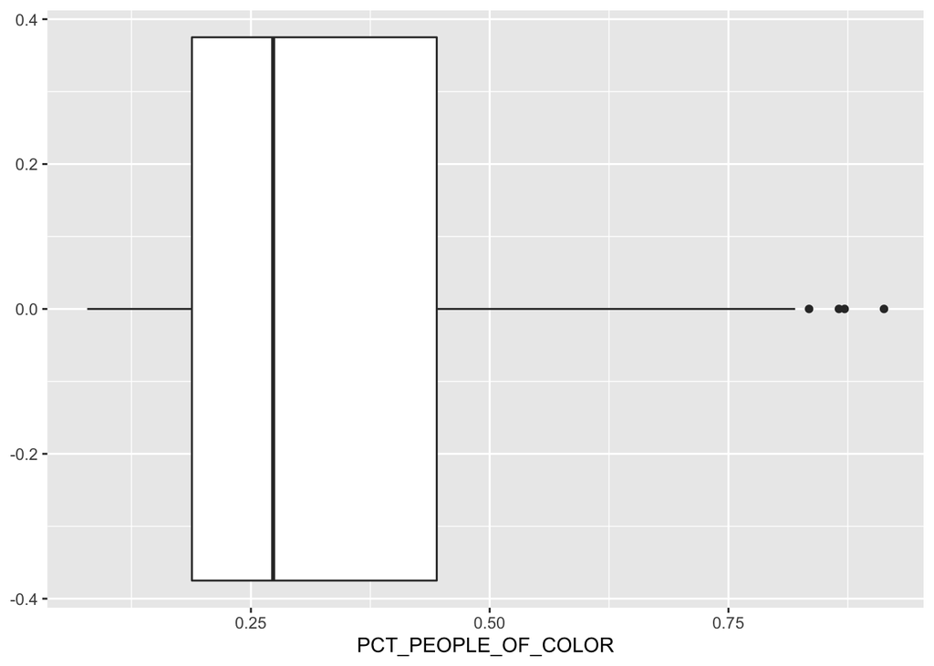

```r
ggplot()+
  geom_boxplot(data=rawdata,mapping=aes(x=PCT_PEOPLE_OF_COLOR))
```

##### From the boxplot, we can tell that there are several neighborhood with extremely high percentage of people with color with the outliers. The median of the percentage is around 0.27.

#### 2.The second numerical variable I would like to include is the percentage of obese adults. I would investigate if or if not the percentage of people of color is linked with percentage of obesity. The range is also from 0 to 1.

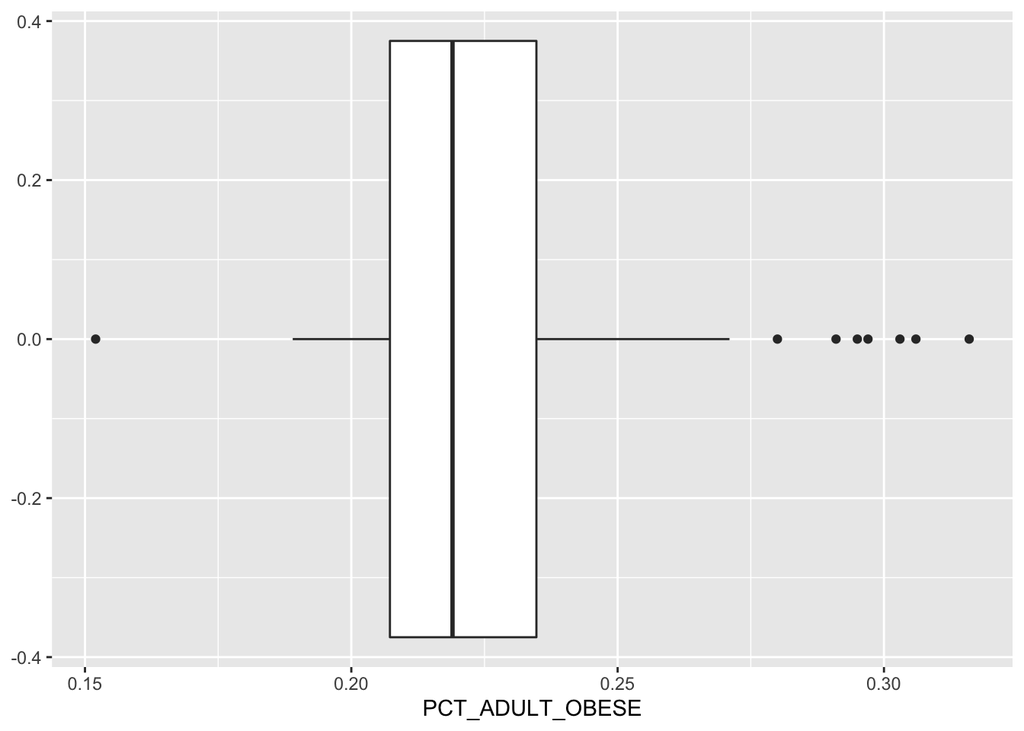

```r
ggplot()+
  geom_boxplot(data=rawdata,mapping=aes(x=PCT_ADULT_OBESE))
```

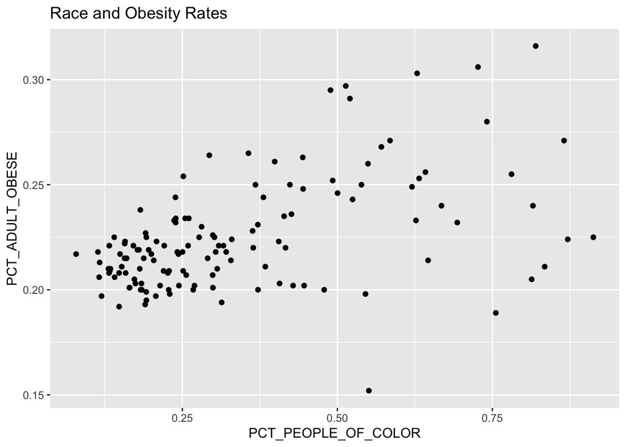

```r
ggplot()+
  geom_point(data=rawdata,mapping=aes(x=PCT_PEOPLE_OF_COLOR,y=PCT_ADULT_OBESE))+geom_smooth()+
  ggtitle("Race and Obesity Rates")
```

##### From the scatter plot, we can tell that there is a positive relationship between people of color and people of obesity, but the linearity is not that significant.